# wk5_d1_hw_howard.Rmd

```r
library(tidyverse)
library(CodeClanData)
library(janitor)
```

# 1 Advanced ggplot2 Homework

## 1.1 2.1 Question 1.

Take the data in the dataset qb_revenue_breakdown and make a stacked bar chart showing the sources of revenue across the two years in the dataset.

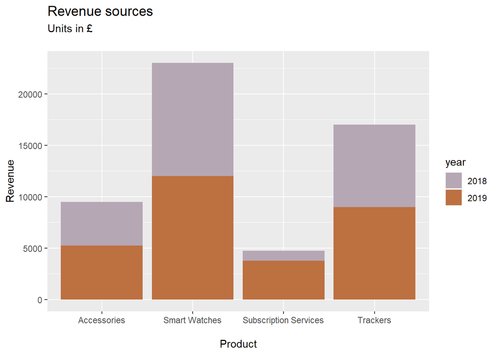

```r
qb_revenue_breakdown %>%
  clean_names()  %>%
  ggplot(aes(x = product, y = revenue, fill = year)) +
  geom_bar(position = "stack", stat = "identity") +
  scale_fill_manual(
    values = c(
      "2018" = "#B6A7B5",
      "2019" = "#BD7040"
    )) +
   labs(
    x        = "\nProduct",
    y        = "Revenue",
    title    = "Revenue sources",
    subtitle = "Units in £\n",
    size = 12
  ) +
  theme(plot.title = element_text(size=14))
```

## 1.2 Questino 2.

Make a line chart showing monthly sales of the “flagship product” - the ‘KwikBit Unit 1’ - over the last year. This data is inside qb_monthly_sales, but you will need to use filter() or subset() (base R).

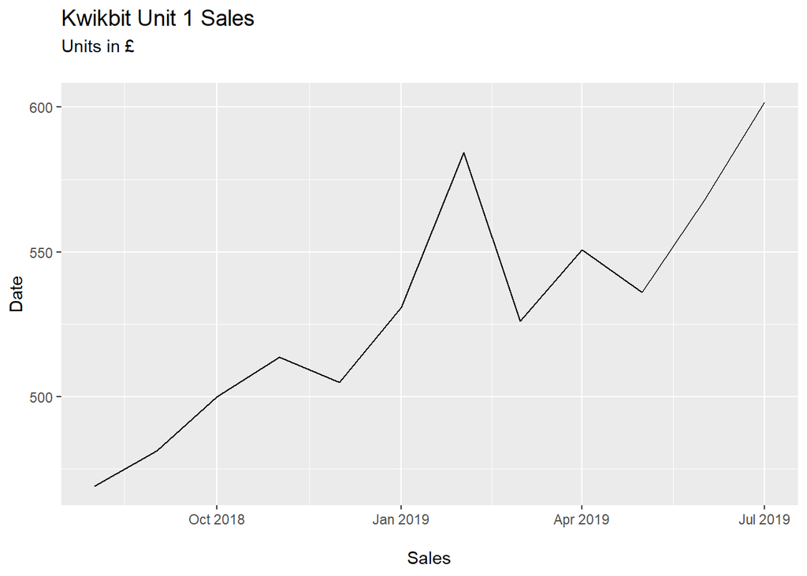

```r
qb_monthly_sales %>%
  clean_names()  %>%
  filter(cashflow == "Kwikbit Unit 1 Sales") %>%
  ggplot() +
  geom_line(aes(x = date, y = amount )) +
  labs(
    x        = "\nSales",
    y        = "Date",
    title    = "Kwikbit Unit 1 Sales",
    subtitle = "Units in £\n",
    size = 12
  ) +
  theme(plot.title = element_text(size=14))
```

## 1.3 Question 3.

Make a line chart showing monthly revenue and costs over the last year. This data is also in qb_monthly_sales.

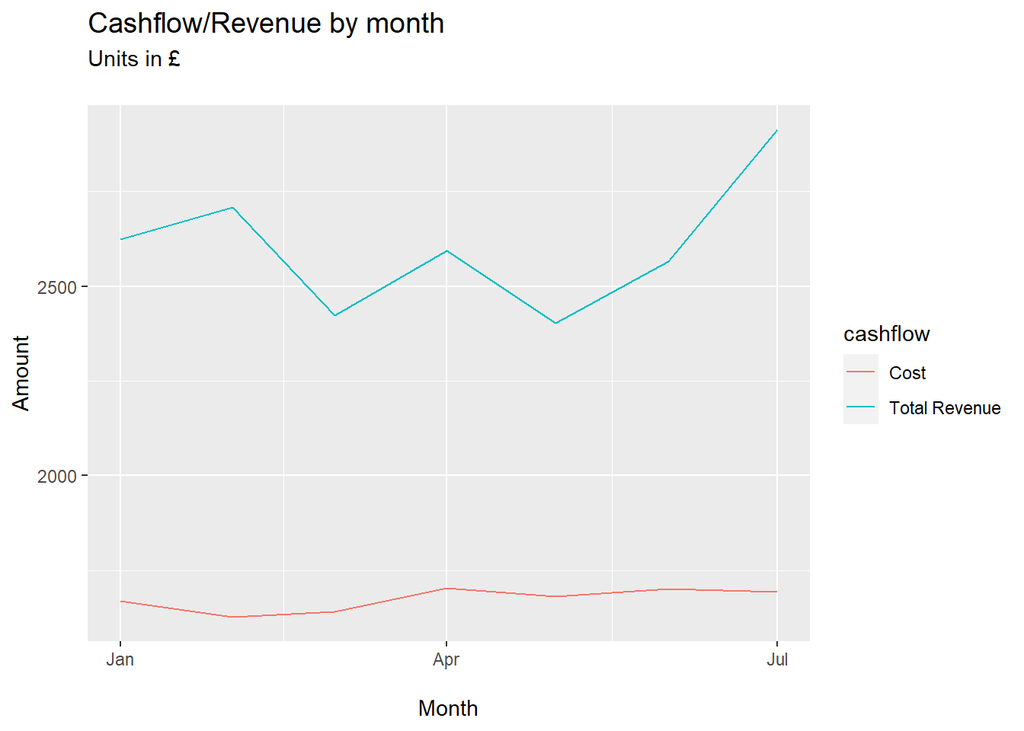

```r
qb_monthly_sales %>%
  clean_names()  %>%
  filter(cashflow %in% c("Total Revenue", "Cost") ) %>%
  filter(date >= "2019-01-01")  %>%
  ggplot() +
  aes(date,amount,colour = cashflow) +
  geom_line()  +
  labs(
    x        = "\nMonth",
    y        = "Amount",
    title    = "Cashflow/Revenue by month",
    subtitle = "Units in £\n",
    size     =  12
  ) +
  theme(plot.title = element_text(size=14))
```

## Question 4.

Show annual sales of personal fitness trackers over the last 5 years broken down by company as a ribbon plot (use geom_area). This data is in qb_competitors.

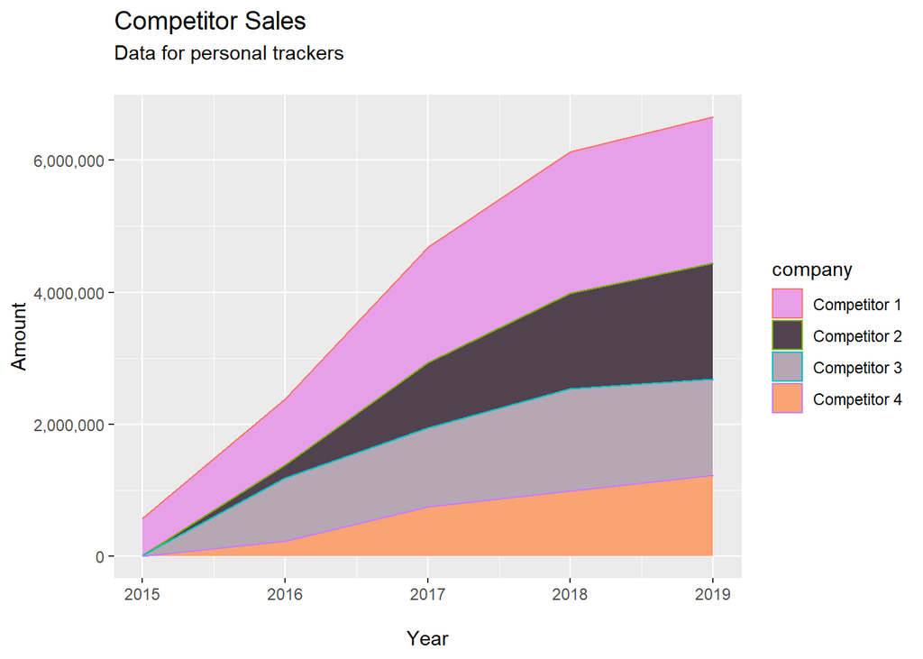

```r
qb_competitors %>%
  clean_names()  %>%
  group_by(company, year)  %>%
  ggplot() +
  aes(year,revenue,colour = company, fill = company) +
  geom_area() +
  scale_fill_manual(
    values = c(
      "Competitor 1" = "#E89FE9",
      "Competitor 2" = "#50434F",
      "Competitor 3" = "#B6A7B5",
      "Competitor 4" = "#F9A472"
    )) +
   scale_y_continuous(labels = scales::comma) +
   labs(
    x        = "\nYear",
    y        = "Amount",
    title    = "Competitor Sales",
    subtitle = "Data for personal trackers\n",
    size     =  12
  ) +
  theme(plot.title = element_text(size=14))
```